# Project 1

Rahmat Ashari

Mar 06, 2020

Abstract

This project objective was to analyze the SWDEFECTS file using R and probability theory. There were four metrics being examined to evaluate software defects: lines of codes, cyclomatic complexity, essential complexity, and design complexity. For each of this metrics, their accuracy, detection rate, false alarm rate, and precision were computed using probability theory. Ultimately, a function was defined to visualize and summarize the assessment of each method. All of the metrics were about 85% accurate with false alarm detection rate less than 20%. Precision ranged between 20-30%. Essential complexity has the highest accuracy but lowest detection rate. Line of code is arguably the best metric to evaluate software defects

[figure not shown]

me lol

# 1 Introduction to the Data

In this section, the data invovled will be described and the variables used for future computations wil be defined.

## 1.1 Data and variables

The SWDEFECTS dataset includes variables that correspond to the metrics used for detecting software defects, with the hope to minimize the possibility of encountering ‘blind spots’ in software evaluation. These metrics were applied to 498 modules of software code written in *C* for NASA spacecraft instrument.

## 1.2 Summary Table and Convention

**The summary table**

|  |  | Defects False | Defects True |
| --- | --- | --- | --- |
| Algorithm | No | a | b |
| Predicts | Yes | c | d |
| Defects |  |  |  |

With the table above defining each variables, we can calculate a number of probabilities that describe the quality and performance of each method to detect software defects:

1. Accuracy

$$P(Algorithm \ is \ correct) = \frac{(a+d)}{(a+b+c+d)}$$
2. Detection rate

$$P(predict \ defect \ | \ module \ has \ defect) = \frac{d}{(b+d)}$$

3. False alarm rate

$$P(predict \ defect \ | \ module \ has \ no \ defect) = \frac{c}{(c+a)}$$

4. Precision

$$P(module \ has \ defect \ | \ predict \ defect) = \frac{d}{(c+d)}$$

# 2 R Functions

The following R chunks create the abovementioned probability functions in R for future use conviniences

1. Accuracy

```r
acc=function(a,b,c,d)
{
  return ((a + d)/(a + b + c + d))
}
```

2. Detection rate

```r
detect=function(b,d)
{
  return ((d) / (b + d))
}
```

3. False alarm rate

```r
falarm=function(a,c)
{
  return ((c) / (a + c))
}
```

4. Precision

```r
prec=function(c,d)
{
  return ((d) / (c + d))
}
```

# 3 Two-way Summary Tables for Each Method

In this section, we need to examine the number of true detect and non detect as described in the summary table for each method. Four metrics are used: lines of codes (LOC), cyclomatic complexity (VG), essential complexity (EVG), and design complexity (IVG). The creation of these tables will assist computations pertaining to the probability theorem in examining the performance and quality of the software defect detection metrics.

```r
swd=read.csv("swdefects.csv")
head(swd)
```

|  | Mloc | Mvg | Mevg | Mivg | Hn | Hvol | Hpgmlen | Hdiff | Hintell | Heffort | Hb | Htime | Hloc | Hcomm | Hblank | loc.comm | uniOp | uniOpnd | totOp | totOpnd | brnchcnt | defect | predict.vg.10 | predict.evg.14.5 | predict.ivg.9.2 | predict.loc.50 |
| --- | --- | --- | --- | --- | --- | --- | --- | --- | --- | --- | --- | --- | --- | --- | --- | --- | --- | --- | --- | --- | --- | --- | --- | --- | --- | --- |
| 1 | 1.1 | 1.4 | 1.4 | 1.4 | 1.3 | 1.3 | 1.30 | 1.30 | 1.30 | 1 | 1.30 | 1 | 2 | 2 | 2 | 2 | 1.2 | 1.2 | 1.2 | 1.2 | 1.4 | FALSE | no | no | no | no |
| 2 | 1.0 | 1.0 | 1.0 | 1.0 | 1.0 | 1.0 | 1.00 | 1.00 | 1.00 | 1 | 1.00 | 1 | 1 | 1 | 1 | 1 | 1.0 | 1.0 | 1.0 | 1.0 | 1.0 | TRUE | no | no | no | no |
| 3 | 24.0 | 5.0 | 1.0 | 3.0 | 63.0 | 309.1 | 0.11 | 9.50 | 32.54 | 2937 | 0.10 | 163 | 1 | 0 | 6 | 0 | 15.0 | 15.0 | 44.0 | 19.0 | 9.0 | FALSE | no | no | no | no |
| 4 | 20.0 | 4.0 | 4.0 | 2.0 | 47.0 | 215.5 | 0.06 | 16.00 | 13.47 | 3448 | 0.07 | 192 | 0 | 0 | 3 | 0 | 16.0 | 8.0 | 31.0 | 16.0 | 7.0 | FALSE | no | no | no | no |
| 5 | 24.0 | 6.0 | 6.0 | 2.0 | 72.0 | 346.1 | 0.06 | 17.33 | 19.97 | 6000 | 0.12 | 333 | 0 | 0 | 3 | 0 | 16.0 | 12.0 | 46.0 | 26.0 | 11.0 | FALSE | no | no | no | no |
| 6 | 24.0 | 6.0 | 6.0 | 2.0 | 72.0 | 346.1 | 0.06 | 17.33 | 19.97 | 6000 | 0.12 | 333 | 0 | 0 | 3 | 0 | 16.0 | 12.0 | 46.0 | 26.0 | 11.0 | FALSE | no | no | no | no |

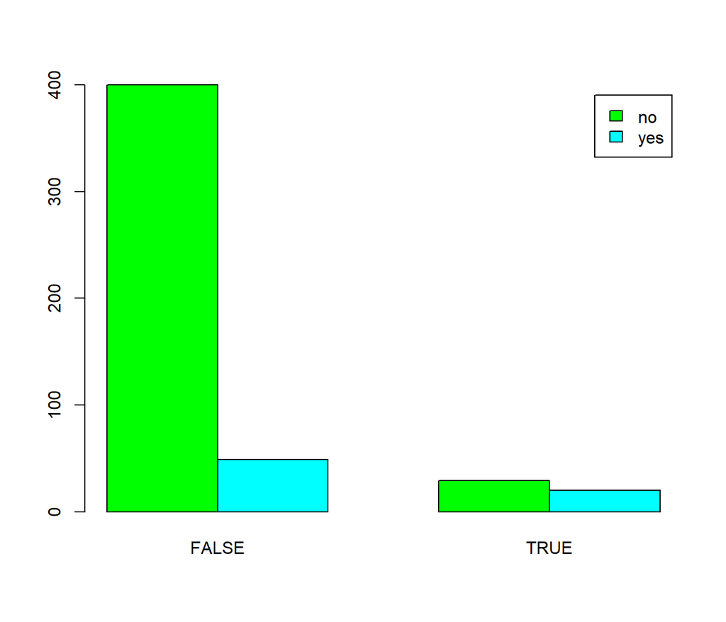

```r
tabRawLoc=with(swd, table(predict.loc.50,defect))
tabRawVG=with(swd, table(predict.vg.10,defect))
tabRawEVG = with(swd, table(predict.evg.14.5,defect))
tabRawIVG = with(swd, table(predict.ivg.9.2,defect))
barplot(tabRawLoc, beside=TRUE, leg=TRUE, col = c('green','cyan'))
```

```r
tabLoc=addmargins(tabRawLoc)
tabLoc
```

```
##               defect
## predict.loc.50 FALSE TRUE Sum
##            no    400   29 429
##            yes    49   20  69
##            Sum   449   49 498
```

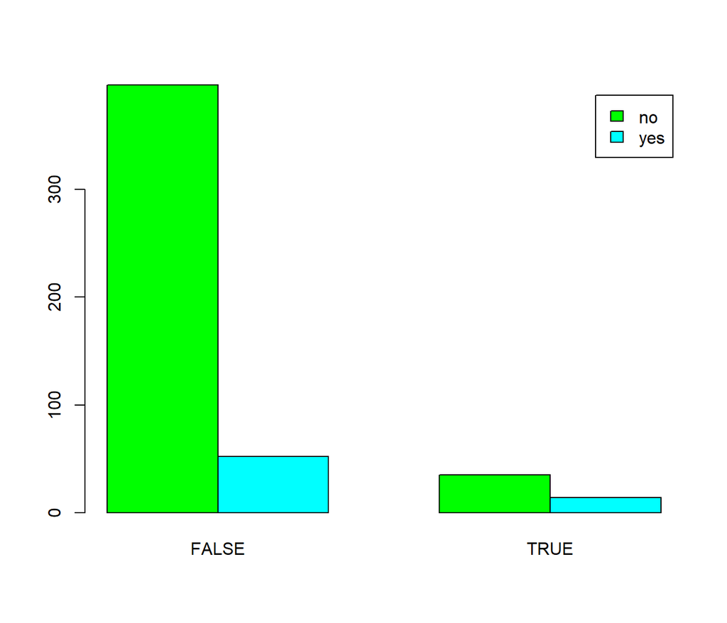

```r
barplot(tabRawVG, beside=TRUE, leg=TRUE, col = c('green','cyan'))
```

```r
tabVG = addmargins(tabRawVG)
tabVG
```

```
##              defect
## predict.vg.10 FALSE TRUE Sum
##           no    397   35 432
##           yes    52   14  66
##           Sum   449   49 498
```

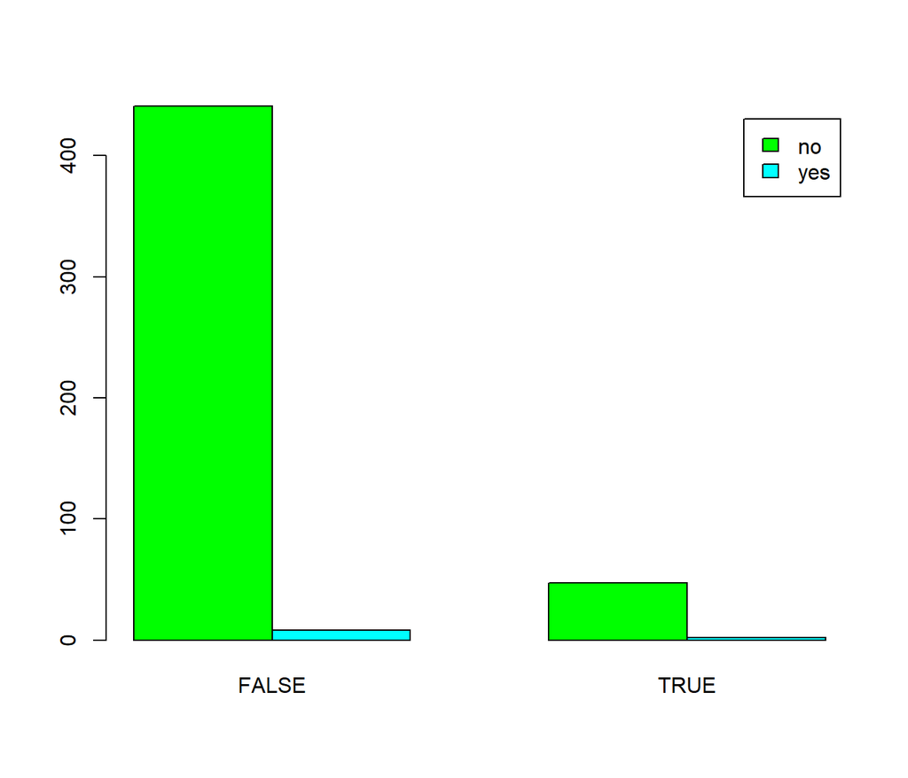

```r
barplot(tabRawEVG, beside=TRUE, leg=TRUE, col = c('green','cyan'))
```

```r
tabEVG = addmargins(tabRawEVG)
tabEVG
```

```
##                 defect
## predict.evg.14.5 FALSE TRUE Sum
##              no    441   47 488
##              yes     8    2  10
##              Sum   449   49 498
```

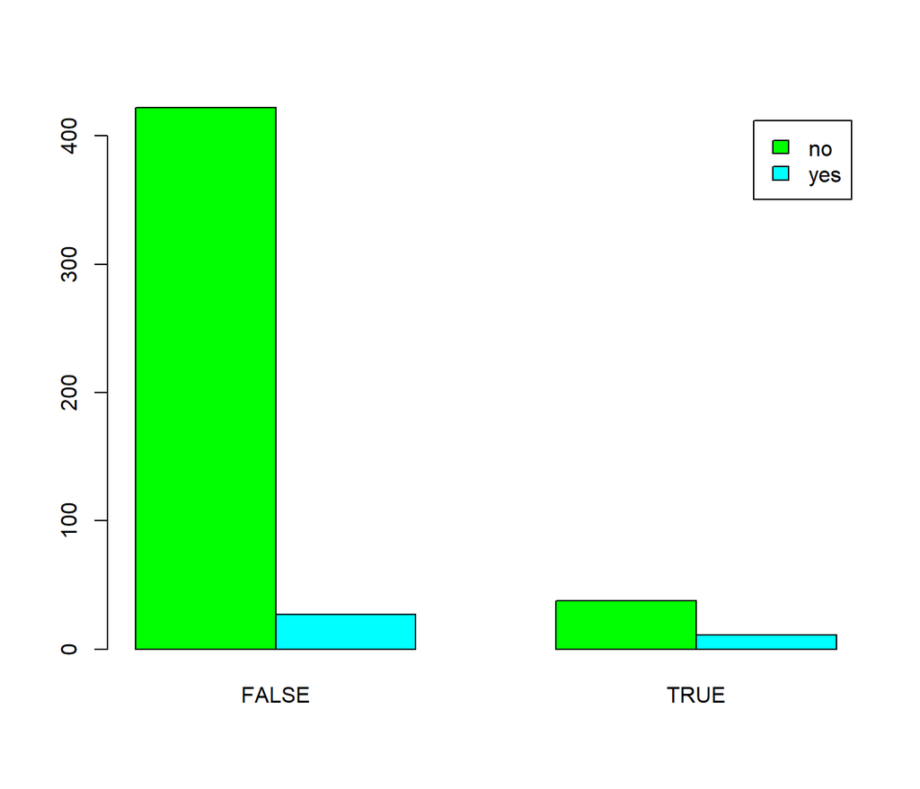

```r
barplot(tabRawIVG, beside=TRUE, leg=TRUE, col = c('green','cyan'))
```

```r
tabIVG = addmargins(tabRawIVG)
tabIVG
```

```
##                defect
## predict.ivg.9.2 FALSE TRUE Sum
##             no    422   38 460
##             yes    27   11  38
##             Sum   449   49 498
```